# Young Women’s Labour-Market Inclusion

## Participation, employment, education and NEET at 18–24 (HSESS)

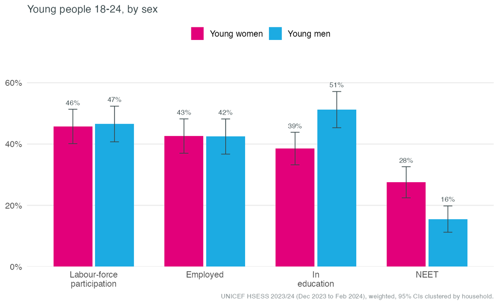

## NEET by age group and sex (HSESS)

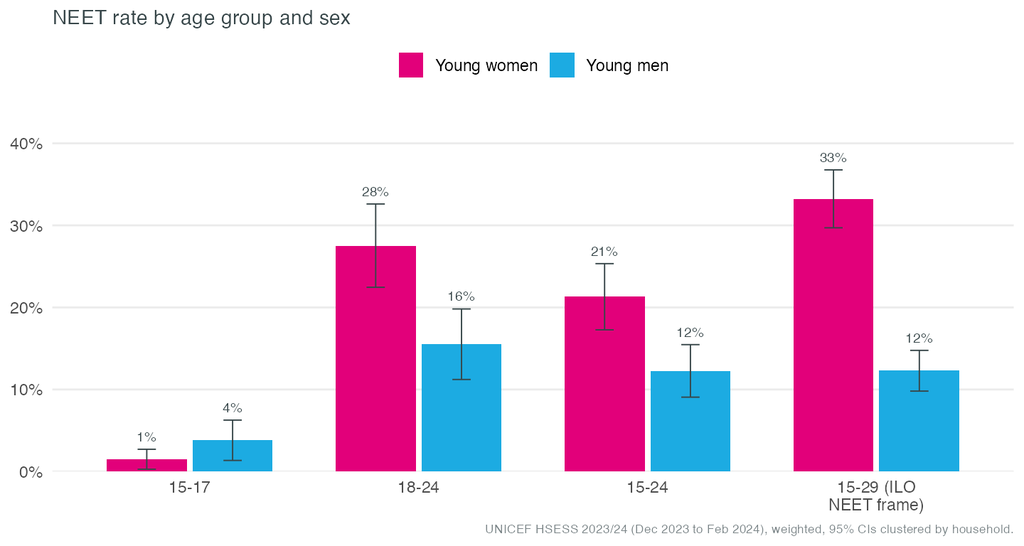

## Reasons for not working, detailed (HSESS)

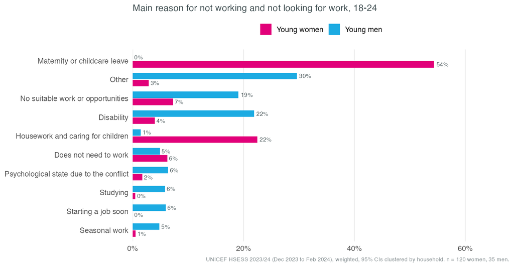

## Informality, hours and wish for more hours at 18–24 (HSESS)

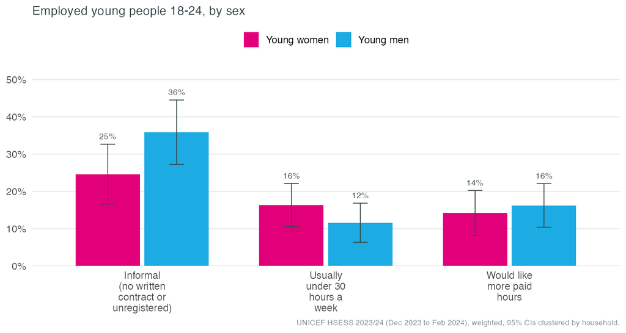

Informal: women 25%, men 36%.

## Monthly and hourly wage gaps (HSESS)

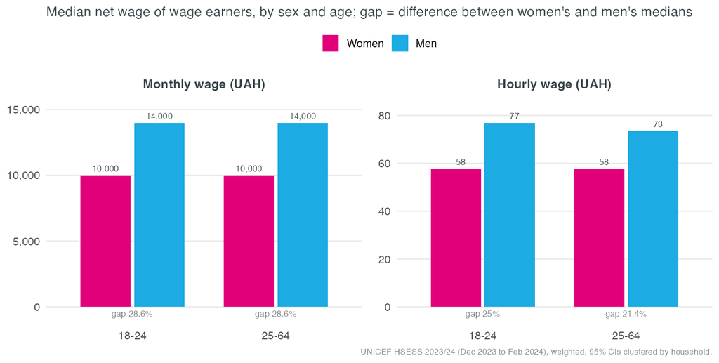

Hourly gap at 18–24: 25%.

## Median wage by education and sex (HSESS)

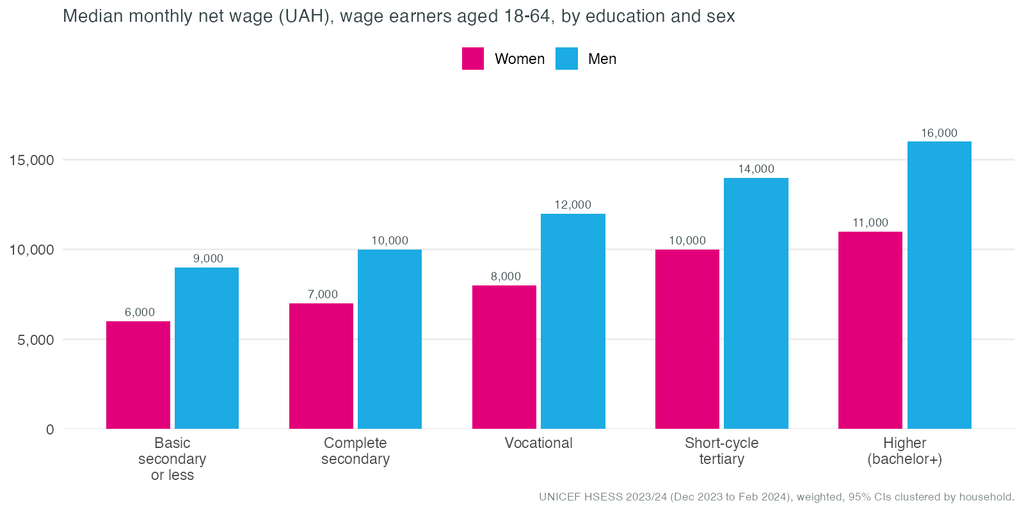

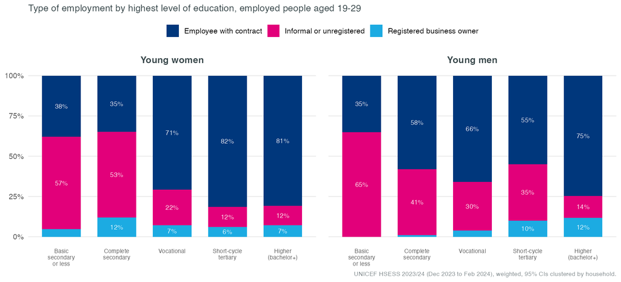

## Women’s share of employment by occupation (HSESS)

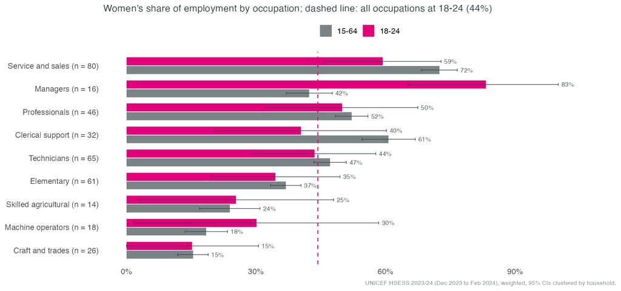

Occupation group as reported by the respondent; groups at 18–24 are small (n shown).

## Wages and years of education (HSESS)

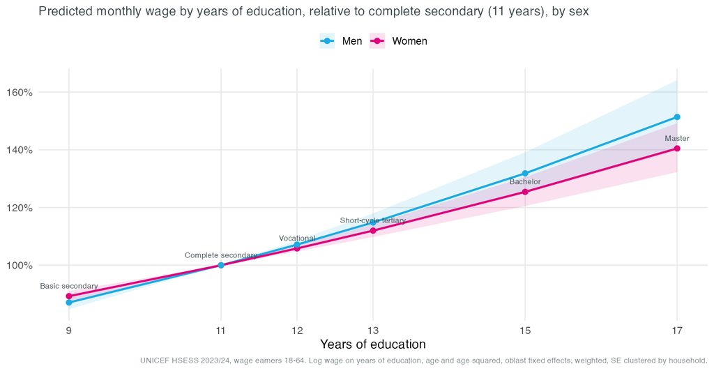

Return per additional year: women 5.8%, men 7.2%.

## Model of NEET, women 18–24 (MICS)

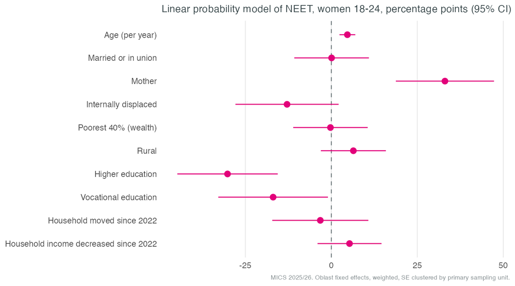

## Adjusted differences in NEET, women 18–24 (MICS)

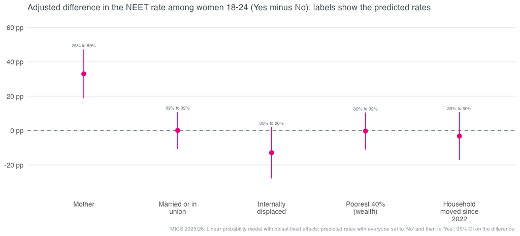

## Model of NEET, ages 18–24 (HSESS)

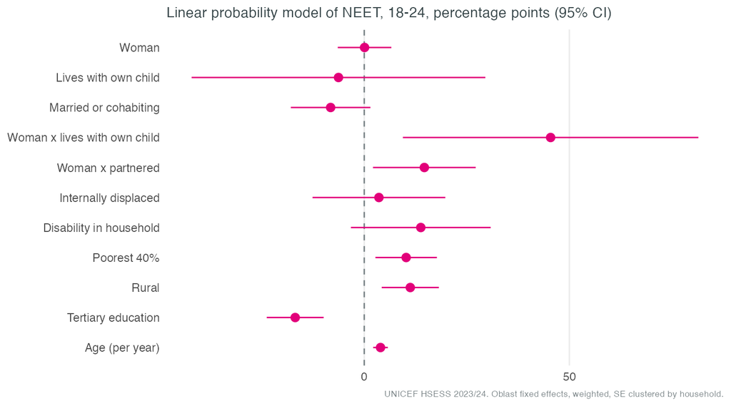

## Adjusted differences in NEET, ages 18–24 (HSESS)

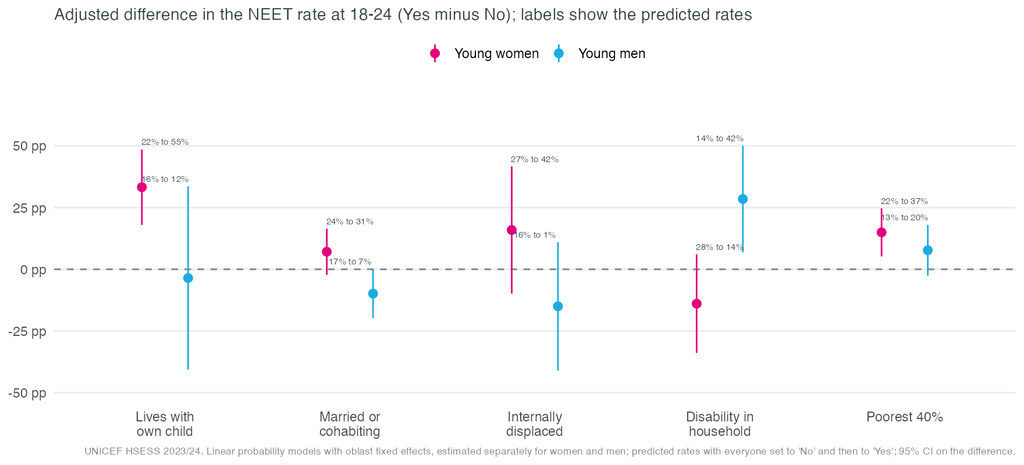

## Adjusted differences in employment, ages 18–24 (HSESS)

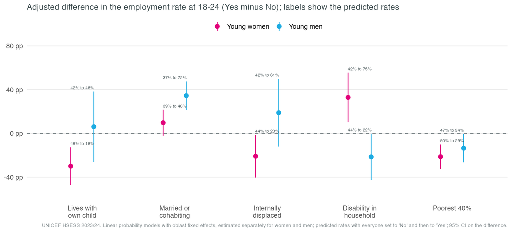

## Estimates, MICS 2025/26

| Estimate | Sample | Effect (pp) | SE | p | N |
| --- | --- | --- | --- | --- | --- |
| NEET: married or in union | Women 18-24 | 0.1 | 5.5 | 0.990 | 709 |
| NEET: mother | Women 18-24 | 33.0 | 7.3 | <0.001 | 709 |
| NEET: married x mother | Women 18-24 | 11.2 | 12.9 | 0.390 | 709 |
| NEET: internally displaced | Women 18-24 | -12.9 | 7.6 | 0.092 | 709 |
| NEET: poorest 40% (wealth) | Women 18-24 | -0.3 | 5.5 | 0.960 | 709 |
| NEET: rural | Women 18-24 | 6.4 | 4.8 | 0.180 | 709 |
| NEET: household moved since 2022 | Women 18-24 | -3.2 | 7.1 | 0.650 | 709 |
| NEET: household income decreased since 2022 | Women 18-24 | 5.3 | 4.7 | 0.260 | 709 |
| NEET: functional difficulty | Women 18-24 | 14.1 | 16.3 | 0.390 | 709 |

Effects in percentage points. Women aged 18–24. Controls: age, marital status, motherhood, displacement, poorest 40%, rural, education level, household moved and household income decreased since 2022, oblast fixed effects. Functional difficulty is estimated for women 18–24.

## Estimates, HSESS 2023/24

| Estimate | Sample | Effect (pp) | SE | p | N |
| --- | --- | --- | --- | --- | --- |
| NEET: women vs men | 18-24 | 6.3 | 3.0 | 0.033 | 1084 |
| NEET: woman x lives with own child | 18-24 | 55.1 | 17.9 | 0.002 | 1084 |
| NEET: woman x married or cohabiting | 18-24 | 21.3 | 6.7 | 0.002 | 1084 |
| NEET: internally displaced | 18-24 | 5.2 | 8.4 | 0.530 | 1084 |
| NEET: person with disability in household | 18-24 | 13.5 | 9.2 | 0.140 | 1084 |
| NEET: poorest 40% of households | 18-24 | 8.9 | 3.9 | 0.021 | 1084 |
| NEET: woman x poorest 40% | 18-24 | 7.7 | 6.7 | 0.250 | 1084 |
| NEET: rural | 18-24 | 12.9 | 3.6 | <0.001 | 1084 |

Effects in percentage points. Ages 18–24. Controls: age, rural, displacement, disability in household, poorest 40%, lives with own child, partnership and tertiary education (except where interacted), oblast fixed effects.

## Returns to education, HSESS 2023/24

| Sample | Return per year (%) | 95% low | 95% high | p | N |
| --- | --- | --- | --- | --- | --- |
| Women 18-64 | 5.8 | 4.8 | 6.9 | <0.001 | 3112 |
| Men 18-64 | 7.2 | 5.7 | 8.6 | <0.001 | 2772 |
| Difference women vs men (interaction) | -0.9 |  |  | 0.230 | 5884 |

Log monthly net wage on years of education, age and age squared, oblast fixed effects, weighted, standard errors clustered by household. Wage earners aged 18–64.

## Association between key variables, women 18–24 (MICS)

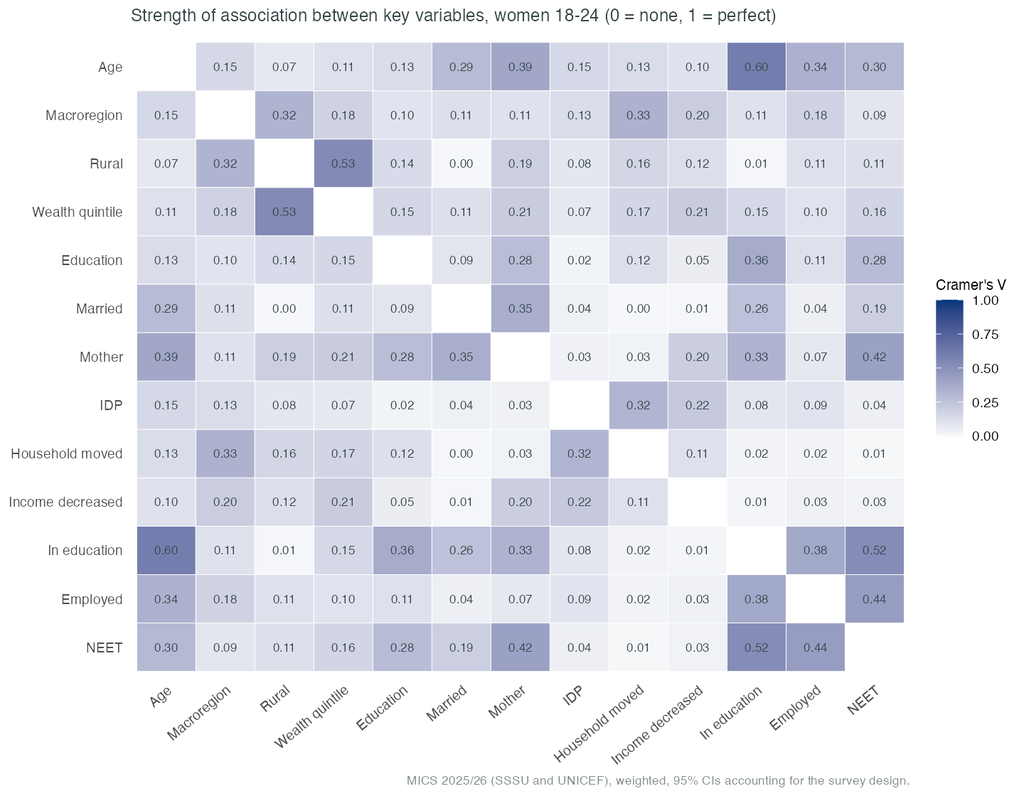

## Association between key variables, ages 18–24 (HSESS)

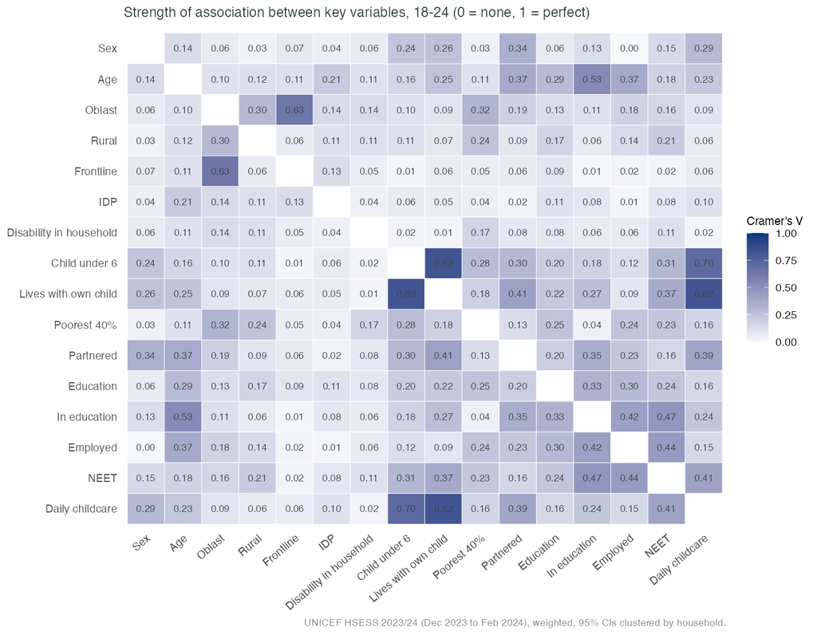

## Reference, Labour Force Survey 2021: outcomes at 15–24 (age released only in bands)

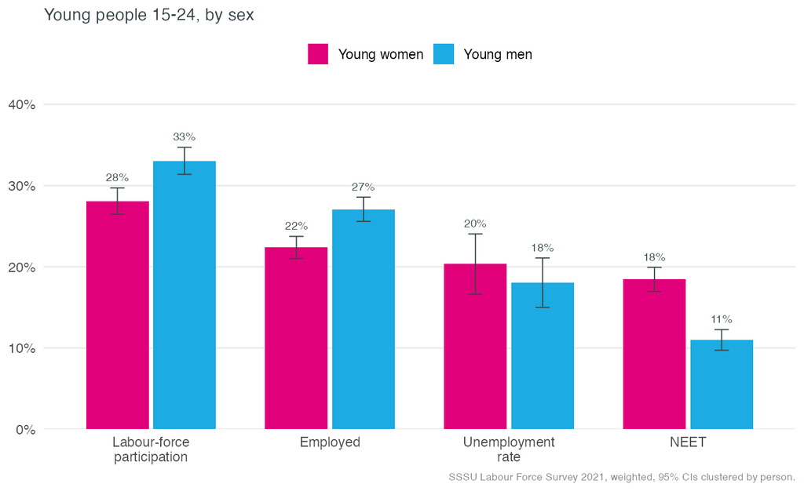

SSSU Labour Force Survey 2021. NEET: women 18%, men 11%. Age is released in bands, so 18–24 cannot be shown.

## Reference, Labour Force Survey 2021: occupations

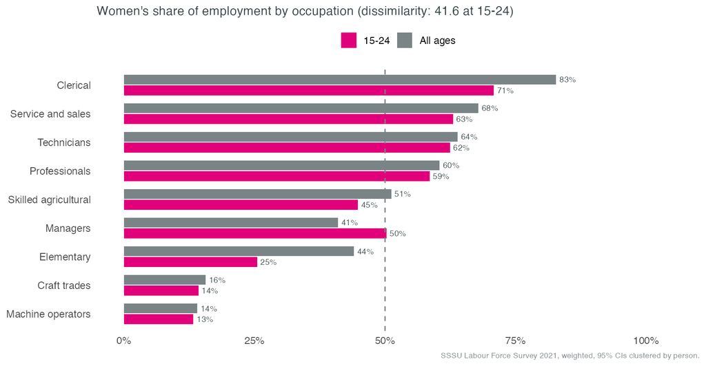

## HSESS variables used

| Variable | Code | Variable | Code | Variable | Code |
| --- | --- | --- | --- | --- | --- |
| key (ind) | questionnaire key | econ_status (ind) | IND_B1 | income_amount (ind) | IND_V1_1_1 |
| weight (ind) | final weight | job_type (ind) | IND_B3_1 | n_children (ind) | dity_n |
| oblast (ind) | OBLAST | sector (ind) | IND_B5_2 | hh_size (ind) | hh_size |
| settlement (ind) | SETTL_TYPE | job_title (ind) | IND_B6_1 | key (hh) | questionnaire key |
| relation (ind) | IND_A1 | occupation (ind) | IND_B6_2 | hh_income (hh) | V1 |
| age (ind) | IND_A2 | hours (ind) | IND_B9_1 | disab_adult (hh) | D1_Mult3 |
| sex (ind) | IND_A3 | attitude (ind) | IND_B10_1 | disab_child (hh) | D1_Mult4 |
| marital (ind) | IND_A6 | why_not_working (ind) | IND_B17_1 | idp_hh (hh) | D1_Mult9 |
| educ_level (ind) | IND_A7 | seeking (ind) | IND_B21 | veteran (hh) | D1_Mult10 |
| in_educ (ind) | IND_A9 | reason_inactive (ind) | IND_B24 | lost_home (hh) | G3_5_1 |
| institution (ind) | IND_A10 | care_children (ind) | IND_B28_1 | damaged_home (hh) | G3_5_2 |
| preschool_reason (ind) | IND_A14 | care_disabled (ind) | IND_B28_3 | wealth (hh) | V16 |
| moved (ind) | IND_A15 | care_elderly (ind) | IND_B28_4 |  |  |
| idp (ind) | IND_A19 | income_source (ind) | IND_V1_1 |  |  |

Codes as in the questionnaire and the “variables_ukr” sheet of each HSESS file; “ind” = individual file, “hh” = household file.